**City College of San Francisco**

MATH 108 - Foundations of Data Science

# Lecture 10: Groups

Associated Textbook Sections: [8.2, 8.3](https://inferentialthinking.com/chapters/08/2/Classifying_by_One_Variable.html)

## Overview

- Francis Galton
- Prediction
- Prediction Accuracy
- Grouping
- Lists
- Pivot Tables

## Set Up the Notebook

```python
from datascience import *
import numpy as np
%matplotlib inline
import matplotlib.pyplot as plots
plots.style.use('fivethirtyeight')
```

## Francis Galton

- 1822 - 1911 (knighted in 1909)
- Charles Darwin's half-cousin
- Developed systems for making predictions in several fields
- An advocate for eugenics and scientific racism

[figure not shown]

If you are not familiar with the concept of eugenics or scientific racism, you might consider watching the following TED-Ed video *The movement that inspired the Holocaust - Alexandra Minna Stern and Natalie Lira*.

**Keep in mind that the content in this video references forced reproductive sterilization and the Holocaust.**

```python
from IPython.display import IFrame

IFrame(src="https://www.youtube.com/embed/6zCpRVP1DgQ?rel=0&amp;controls=0&amp;showinfo=0", width="560", height="315")
```

[video not shown]

## Prediction

### Demo: Prediction

Load the Galton's data and visualize the relationship between `midparentHeight` and `childHeight`.

```python
# Question: can we predict children's height from parents' height?
# Import table. midparentHeight is average of two parents' heights.

galton = Table.read_table('./data/galton.csv')
galton
```

| family | father | mother | midparentHeight | children | childNum | sex | childHeight |
| --- | --- | --- | --- | --- | --- | --- | --- |
| 1 | 78.5 | 67 | 75.43 | 4 | 1 | male | 73.2 |
| 1 | 78.5 | 67 | 75.43 | 4 | 2 | female | 69.2 |
| 1 | 78.5 | 67 | 75.43 | 4 | 3 | female | 69 |
| 1 | 78.5 | 67 | 75.43 | 4 | 4 | female | 69 |
| 2 | 75.5 | 66.5 | 73.66 | 4 | 1 | male | 73.5 |
| 2 | 75.5 | 66.5 | 73.66 | 4 | 2 | male | 72.5 |
| 2 | 75.5 | 66.5 | 73.66 | 4 | 3 | female | 65.5 |
| 2 | 75.5 | 66.5 | 73.66 | 4 | 4 | female | 65.5 |
| 3 | 75 | 64 | 72.06 | 2 | 1 | male | 71 |
| 3 | 75 | 64 | 72.06 | 2 | 2 | female | 68 |

... (924 rows omitted)

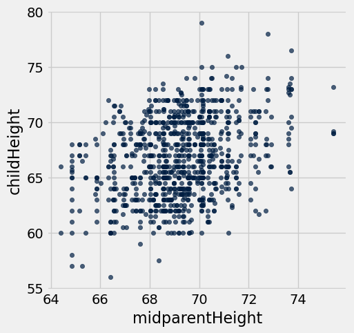

```python
# Look at visualization (put predictor on x-axis)

galton.scatter('midparentHeight', 'childHeight')
```

Identify points that are within 0.5 of the `midparentHeight` value of 68.

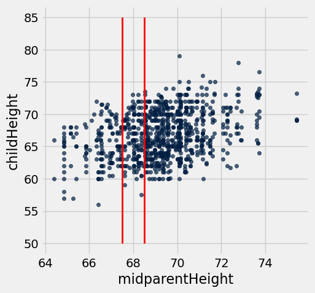

```python
# Thoughts about how we use this?
# Question: How to predict child's height for parents with midheight of 68 inches?
# going for points within 0.5 in. of midparentheight of 68 (red lines plotted)
# and then looking at average childHeight for that set

galton.scatter('midparentHeight', 'childHeight')
plots.plot([67.5, 67.5], [50, 85], color='red', lw=2)
plots.plot([68.5, 68.5], [50, 85], color='red', lw=2);
```

```python
nearby = galton.where('midparentHeight', are.between(67.5, 68.5))
nearby_mean = np.average(nearby.column('childHeight'))
nearby_mean
```

```
66.24045801526718
```

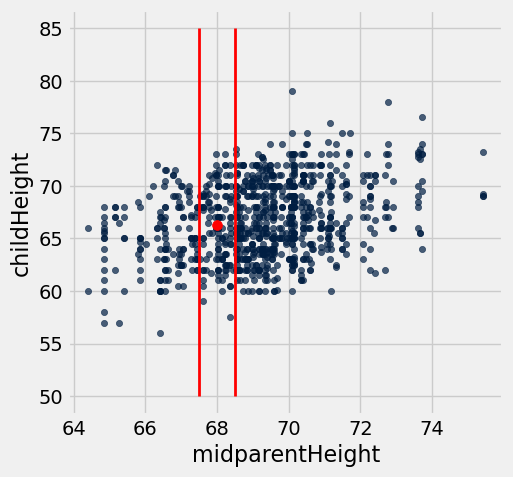

```python
# to see the average childheight calculated for that nearby set

galton.scatter('midparentHeight', 'childHeight')
plots.plot([67.5, 67.5], [50, 85], color='red', lw=2)
plots.plot([68.5, 68.5], [50, 85], color='red', lw=2)
plots.scatter(68, nearby_mean, color='red', s=50);
```

Create a function to predict the height of a child based on the average `childHeight` associated with the points within 0.5 of the given child's `midparentHeight` value.

```python
# Now, we try to make our prediction model.

def predict(h):
    nearby = galton.where('midparentHeight', are.between(h - 0.5, h + 0.5))
    return np.average(nearby.column('childHeight'))
```

```python
predict(68)
```

```
66.24045801526718
```

```python
predict(70)
```

```
67.272850678733022
```

```python
predict(73)
```

```
69.5
```

Apply the function to the `galton` table.

```python
# to make a new column in Galton table of predicted child heights
# use apply to the midparentHeight column

predicted_heights = galton.apply(predict, 'midparentHeight')
predicted_heights
```

```
array([ 70.1       ,  70.1       ,  70.1       ,  70.1       ,
        70.41578947,  70.41578947,  70.41578947,  70.41578947,
        68.5025    ,  68.5025    ,  68.5025    ,  68.5025    ,
        68.5025    ,  68.5025    ,  68.5025    ,  66.43149606,
        66.43149606,  66.43149606,  66.43149606,  66.43149606,
        66.43149606,  70.41578947,  70.41578947,  70.41578947,
        70.41578947,  70.41578947,  70.41578947,  70.41578947,
        69.18571429,  69.18571429,  69.18571429,  69.18571429,
        68.66052632,  67.63423913,  67.63423913,  67.63423913,
        67.63423913,  67.63423913,  67.63423913,  67.63423913,
        67.63423913,  67.37410714,  68.77428571,  68.77428571,
        68.77428571,  68.77428571,  68.59230769,  68.59230769,
        68.59230769,  68.07323944,  68.07323944,  68.07323944,
        68.07323944,  68.07323944,  68.07323944,  68.07323944,
        68.07323944,  68.07323944,  68.05465116,  68.05465116,
        68.05465116,  68.05465116,  68.05465116,  68.05465116,
        67.56276596,  67.56276596,  67.56276596,  67.71678832,
        70.41578947,  70.41578947,  70.41578947,  70.41578947,
        70.41578947,  70.41578947,  70.41578947,  70.41578947,
        68.628125  ,  68.628125  ,  68.628125  ,  68.54193548,
        68.54193548,  68.54193548,  67.66941176,  67.66941176,
        67.66941176,  67.66941176,  67.66941176,  67.66941176,
        67.66941176,  68.05357143,  67.63352941,  67.63352941,
        67.36355556,  67.36355556,  67.36355556,  67.36355556,
        67.36355556,  67.36355556,  67.36355556,  67.36355556,
        67.36355556,  67.36355556,  67.36355556,  67.36355556,
        67.36355556,  67.36355556,  67.63352941,  67.63352941,
        67.63352941,  66.75884956,  67.11255061,  67.11255061,
        67.11255061,  67.11255061,  67.11255061,  67.11255061,
        66.75884956,  66.75884956,  66.75884956,  66.75884956,
        66.75884956,  66.75884956,  66.75884956,  66.75884956,
        66.75884956,  66.75884956,  66.23647541,  68.628125  ,
        68.628125  ,  68.628125  ,  68.628125  ,  68.628125  ,
        67.97333333,  67.97333333,  67.97333333,  67.97333333,
        67.85      ,  67.85      ,  67.85      ,  67.85      ,
        67.85      ,  67.85      ,  67.85      ,  67.85      ,
        67.85      ,  67.85      ,  67.85      ,  67.85      ,
        67.85      ,  67.85      ,  67.85      ,  67.85      ,
        67.85      ,  67.97294118,  67.8661157 ,  67.8661157 ,
        67.8661157 ,  67.8661157 ,  67.8661157 ,  67.8661157 ,
```

[output cut: 179 more lines]

```
        66.36513761,  66.36513761,  66.36513761,  66.36513761,
        66.36513761,  66.36513761,  65.99259259,  65.99259259,
        66.36513761,  66.36513761,  66.36513761,  66.36513761,
        66.36513761,  66.36513761,  65.55833333,  65.55833333,
        65.55833333,  65.55833333,  65.55833333,  65.55833333,
        65.21690141,  65.21690141,  65.21690141,  65.21690141,
        65.21690141,  65.36296296,  65.36296296,  65.36296296,
        65.36296296,  64.22962963,  64.22962963,  64.22962963,
        64.22962963,  64.22962963,  65.2943662 ,  65.2943662 ,
        65.2943662 ,  65.2943662 ,  65.2943662 ,  65.2943662 ,
        65.2943662 ,  65.2943662 ,  65.2943662 ,  65.2943662 ,
        65.2943662 ,  65.2943662 ,  65.2943662 ,  65.2943662 ,
        64.42121212,  63.51176471,  63.51176471,  65.11      ,
        65.11      ,  65.15657895,  65.15657895,  65.15657895,
        64.22962963,  64.22962963])
```

```python
# attach to table

galton = galton.with_columns('predictedHeight', predicted_heights)
galton.show(5)
```

| family | father | mother | midparentHeight | children | childNum | sex | childHeight | predictedHeight |
| --- | --- | --- | --- | --- | --- | --- | --- | --- |
| 1 | 78.5 | 67 | 75.43 | 4 | 1 | male | 73.2 | 70.1 |
| 1 | 78.5 | 67 | 75.43 | 4 | 2 | female | 69.2 | 70.1 |
| 1 | 78.5 | 67 | 75.43 | 4 | 3 | female | 69 | 70.1 |
| 1 | 78.5 | 67 | 75.43 | 4 | 4 | female | 69 | 70.1 |
| 2 | 75.5 | 66.5 | 73.66 | 4 | 1 | male | 73.5 | 70.4158 |

... (929 rows omitted)

Visualize the predictions.

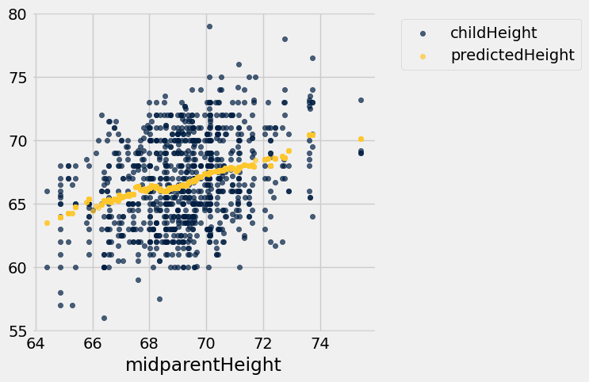

```python
# overlay the predictions on the original plot
# select the 3 vars and then do a scatter on the midparentHeight and it will show a plot
# with the other two against that (color coded)

galton.select(
    'midparentHeight', 'childHeight', 'predictedHeight').scatter('midparentHeight')
```

## Prediction Accuracy

### Demo: Prediction Accuracy

Define a function to compute the difference `x - y` between two values `x` and `y`.

```python
def difference(x, y):
    return x - y
```

Apply the function to the `galton` table to measure the difference between the `predictedHeight` and `childHeight` values. Add the results to the table.

```python
# error = predicted value minus actual value

# Amy's brute force way
# pred_errs = galton.column('predictedHeight') - galton.column('childHeight')


pred_errs = galton.apply(difference, 'predictedHeight', 'childHeight')
pred_errs
```

```
array([ -3.10000000e+00,   9.00000000e-01,   1.10000000e+00,
         1.10000000e+00,  -3.08421053e+00,  -2.08421053e+00,
         4.91578947e+00,   4.91578947e+00,  -2.49750000e+00,
         5.02500000e-01,  -1.99750000e+00,   2.50000000e-03,
         1.50250000e+00,   4.00250000e+00,   5.50250000e+00,
        -5.56850394e+00,  -2.56850394e+00,  -1.56850394e+00,
        -6.85039370e-02,   3.93149606e+00,   3.93149606e+00,
         9.15789474e-01,  -6.08421053e+00,  -3.58421053e+00,
        -2.58421053e+00,  -2.58421053e+00,  -8.42105263e-02,
         6.41578947e+00,  -1.31428571e+00,   1.18571429e+00,
         3.18571429e+00,   3.18571429e+00,   3.16052632e+00,
        -6.36576087e+00,  -2.36576087e+00,  -3.65760870e-01,
         6.34239130e-01,   6.34239130e-01,   1.63423913e+00,
         4.13423913e+00,   4.63423913e+00,   2.37410714e+00,
        -2.22571429e+00,   6.77428571e+00,   7.74285714e-01,
         1.77428571e+00,  -2.40769231e+00,  -1.90769231e+00,
         1.89230769e+00,  -3.92676056e+00,  -2.42676056e+00,
        -2.12676056e+00,  -2.12676056e+00,  -1.12676056e+00,
        -6.26760563e-01,   1.57323944e+00,   3.57323944e+00,
         4.57323944e+00,  -5.94534884e+00,  -4.94534884e+00,
        -3.44534884e+00,   5.55465116e+00,   1.55465116e+00,
         5.75465116e+00,   1.56276596e+00,   3.06276596e+00,
         3.56276596e+00,   5.01678832e+00,  -2.78421053e+00,
        -2.58421053e+00,  -2.28421053e+00,   4.15789474e-01,
         1.41578947e+00,   1.91578947e+00,   2.41578947e+00,
         4.41578947e+00,  -4.37187500e+00,   1.28125000e-01,
         6.28125000e-01,  -4.45806452e+00,  -2.45806452e+00,
         1.54193548e+00,  -6.53058824e+00,  -2.83058824e+00,
        -1.83058824e+00,   1.66941176e+00,   2.16941176e+00,
         2.66941176e+00,   2.66941176e+00,   2.55357143e+00,
         1.63352941e+00,   4.63352941e+00,  -3.13644444e+00,
        -3.13644444e+00,  -1.63644444e+00,   2.36355556e+00,
         4.36355556e+00,  -1.63644444e+00,   3.63555556e-01,
         4.36355556e+00,  -5.63644444e+00,   3.63555556e-01,
        -3.13644444e+00,  -2.63644444e+00,   8.63555556e-01,
         4.36355556e+00,   1.33529412e-01,   4.33529412e-01,
         9.33529412e-01,   2.75884956e+00,  -3.88744939e+00,
        -2.88744939e+00,  -2.88744939e+00,   1.11255061e+00,
         2.11255061e+00,   2.11255061e+00,  -7.24115044e+00,
        -5.24115044e+00,  -2.24115044e+00,  -7.41150442e-01,
```

[output cut: 257 more lines]

```
        -1.44166667e+00,   1.55833333e+00,   1.55833333e+00,
         3.05833333e+00,   5.05833333e+00,  -4.78309859e+00,
         2.21690141e+00,  -7.83098592e-01,  -7.83098592e-01,
         2.21690141e+00,  -5.63703704e+00,  -5.63703704e+00,
        -3.63703704e+00,   1.86296296e+00,  -3.77037037e+00,
        -3.77037037e+00,  -2.77037037e+00,  -2.77037037e+00,
         2.22962963e+00,  -6.20563380e+00,  -2.70563380e+00,
        -2.05633803e-01,   1.29436620e+00,   3.29436620e+00,
         3.29436620e+00,   4.29436620e+00,  -5.20563380e+00,
        -2.70563380e+00,  -1.70563380e+00,   2.94366197e-01,
         1.29436620e+00,   1.29436620e+00,   5.29436620e+00,
        -7.87878788e-02,  -2.48823529e+00,   3.51176471e+00,
        -3.39000000e+00,   1.61000000e+00,   1.15657895e+00,
         3.15657895e+00,   4.15657895e+00,  -2.27037037e+00,
         7.22962963e+00])
```

```python
galton = galton.with_columns('errors', pred_errs)
galton
```

| family | father | mother | midparentHeight | children | childNum | sex | childHeight | predictedHeight | errors |
| --- | --- | --- | --- | --- | --- | --- | --- | --- | --- |
| 1 | 78.5 | 67 | 75.43 | 4 | 1 | male | 73.2 | 70.1 | -3.1 |
| 1 | 78.5 | 67 | 75.43 | 4 | 2 | female | 69.2 | 70.1 | 0.9 |
| 1 | 78.5 | 67 | 75.43 | 4 | 3 | female | 69 | 70.1 | 1.1 |
| 1 | 78.5 | 67 | 75.43 | 4 | 4 | female | 69 | 70.1 | 1.1 |
| 2 | 75.5 | 66.5 | 73.66 | 4 | 1 | male | 73.5 | 70.4158 | -3.08421 |
| 2 | 75.5 | 66.5 | 73.66 | 4 | 2 | male | 72.5 | 70.4158 | -2.08421 |
| 2 | 75.5 | 66.5 | 73.66 | 4 | 3 | female | 65.5 | 70.4158 | 4.91579 |
| 2 | 75.5 | 66.5 | 73.66 | 4 | 4 | female | 65.5 | 70.4158 | 4.91579 |
| 3 | 75 | 64 | 72.06 | 2 | 1 | male | 71 | 68.5025 | -2.4975 |
| 3 | 75 | 64 | 72.06 | 2 | 2 | female | 68 | 68.5025 | 0.5025 |

... (924 rows omitted)

Visualize the errors in prediction.

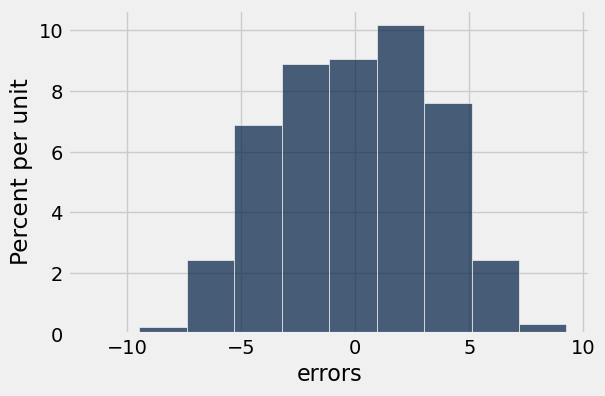

```python
# Let's visualize the errors! (with a histogram)

galton.hist('errors')
```

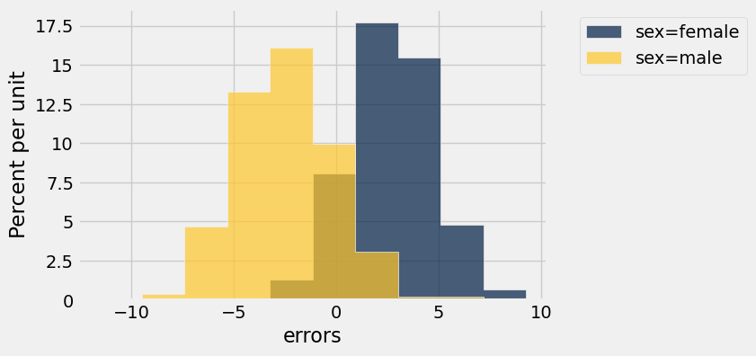

```python
# This is a very wide range. We can predict the heights within 10 inches?
# What are we missing? Can we do better?

galton.hist('errors', group = 'sex')


# We are predicting the females to be taller than they are and the males to be shorter
# than they are. And there are two distinct groups.
```

## Grouping

### Grouping by One Column

The group method aggregates all rows with the same value for a column into a single row in the resulting table.

- First argument: Which column to group by
- Second argument: (Optional) How to combine values
  - `len` — number of grouped values (default)
  - `list` — list of all grouped values
  - `sum` — total of all grouped values
  - ...

```python
from IPython.display import IFrame
IFrame('https://docs.google.com/presentation/d/e/2PACX-1vT5DQDrDs21XnYnUD1000G97wukT1oj9N\
_ePPTdmGTp2vPh88jW_JCLcoK2yaWmmLjKjXelJDnT4m-J/embed?start=false&loop=false&delayms=3000', 800, 600)
```

[interactive chart not shown]

### Demo: Grouping by One Column

Load the `cones.csv` data and explore the `group` method.

```python
cones = Table.read_table('./data/cones.csv')
cones
```

| Flavor | Color | Price |
| --- | --- | --- |
| strawberry | pink | 3.55 |
| chocolate | light brown | 4.75 |
| chocolate | dark brown | 5.25 |
| strawberry | pink | 5.25 |
| chocolate | dark brown | 5.25 |
| bubblegum | pink | 4.75 |

```python
# to group by Flavor

cones.group('Flavor')
```

| Flavor | count |
| --- | --- |
| bubblegum | 1 |
| chocolate | 3 |
| strawberry | 2 |

```python
# Q: What is the average price for each flavor?
# We drop the color column and group by flavor and call average.

# Show this first. It will try to find the average of all the other columns.
# cones.group('Flavor', np.average)

cones.drop('Color').group('Flavor', np.average)
```

| Flavor | Price average |
| --- | --- |
| bubblegum | 4.75 |
| chocolate | 5.08333 |
| strawberry | 4.4 |

```python
# Q: What is the minimum price for each flavor?
# We drop the color column and group by flavor and call min.

# Show this first. It will find the min of all the other columns (makes sense for alphabetical).
# cones.group('Flavor', min)

cones.drop('Color').group('Flavor', min)
```

| Flavor | Price min |
| --- | --- |
| bubblegum | 4.75 |
| chocolate | 4.75 |
| strawberry | 3.55 |

### Demo: Grouping By One Column: Welcome Survey

Explore the `group` method using the `welcome_survey_sp23.csv` data. Include some visualizations based on the grouped data.

```python
survey = Table.read_table('./data/welcome_survey_sp23.csv')
survey.show(3)
```

| Time | Section | Birthday | Age | DA Cert | DS AS | Born in US | Reaction Time (ms) | Math Experience | Prior Python Experience | Sunrise or Sunset | Weekly Time on Assignments | Career Change | Commute Duration | Required Weekly Work Hours | Zipcode | Programming Language Experience | Number of Countries | Top Movie Genres | Favorite SF Season | Highest Education Level | Veteran | Personality Type | MATH 108 Work Times | Data Science Career Goal | MATH 108 Work Days | Tutoring Format Preference | Sequence Length | Time in San Francisco | Statistics Experience | … |
| --- | --- | --- | --- | --- | --- | --- | --- | --- | --- | --- | --- | --- | --- | --- | --- | --- | --- | --- | --- | --- | --- | --- | --- | --- | --- | --- | --- | --- | --- | --- |
| 2/9/2023 14:23:02 | A | 3/9 | 21 | No | No | Yes | nan | 4 | No | Sunsets | 10 | No | 1:15:00 | 20 | 94703 | nan | 4 | Action & Adventure, Comedies, Sci-fi & Fantasy | Summer | Some college but not a degree | No | Ambivert | 6 am - 10 am, 2 pm - 6 pm | Yes | Thursday, Sunday | In person | nan | 1 | 10 | … |
| 2/9/2023 15:43:41 | A | 4/25 | 35 | Maybe | Maybe | Yes | 283 | 3 | No | Sunrises | 7 | No | 1:30:00 | 28 | 94510 | 2 | 7 | Classic, Comedies, Dramas | Summer | High school graduate | Yes | Introvert | 2 pm - 6 pm, 6 pm - 10 pm | Maybe | Monday, Wednesday | Neither | 11 | 3 | 1 | … |
| 2/9/2023 21:03:44 | A | 7/2 | 21 | No | No | No | 264 | 4 | Yes | Sunsets | 8 | No | 0:30:00 | 18 | 94112 | 3 | 3 | Action & Adventure, Anime, Sci-fi & Fantasy | Spring | Some college but not a degree | No | Introvert | 10 am - 2 pm, 6 pm - 10 pm | Maybe | Friday, Sunday | In person | 10 | 6 | 7 | … |

... (40 rows omitted)

```python
# Q: Does tutoring format preference have an effect on reaction time and/or sequence length?

tutoring_reaction_sequence = survey.select('Tutoring Format Preference', 'Reaction Time (ms)', 'Sequence Length')

tutoring_reaction_sequence = (tutoring_reaction_sequence.where('Tutoring Format Preference', are.not_equal_to('nan'))
                              .where('Reaction Time (ms)', are.above_or_equal_to(0))
                              .where('Sequence Length', are.above_or_equal_to(0)))

# to see the tutoring preferences effect on reaction times and sequence length

tutoring_reaction_sequence.group('Tutoring Format Preference', np.median)
```

| Tutoring Format Preference | Reaction Time (ms) median | Sequence Length median |
| --- | --- | --- |
| In person | 298 | 10 |
| Neither | 298.5 | 12 |
| Virtually | 281 | 11 |

```python
# Q: Is how prepared people felt for Math 108 a result of Programming
# and Statistics experience?


prep_programming_statistics = survey.select('MATH 108 Prep Feeling',
                                            'Programming Language Experience',
                                            'Statistics Experience')

prep_programming_statistics = (prep_programming_statistics
                               .where('Programming Language Experience', are.above_or_equal_to(0))
                               .where('Statistics Experience', are.above_or_equal_to(0)))


prep_programming_statistics.group('MATH 108 Prep Feeling', np.average)
```

| MATH 108 Prep Feeling | Programming Language Experience average | Statistics Experience average |
| --- | --- | --- |
| 1 | 1.33333 | 2.22222 |
| 2 | 3.5 | 2.5 |
| 3 | 2 | 4 |
| 4 | 3 | 7 |
| 5 | 3 | 4.9 |
| 6 | 3.66667 | 4.16667 |
| 8 | 6.33333 | 2.33333 |
| 9 | 5.33333 | 5.33333 |
| 10 | 8 | 7 |

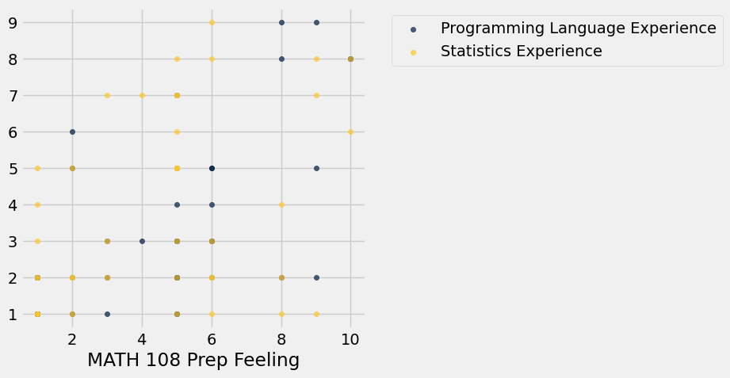

```python
# could try a visual

prep_programming_statistics.scatter('MATH 108 Prep Feeling')
```

## Lists

### Lists are Generic Sequences

- A list is a sequence of values (just like an array), but the values can all have different types:

> `[2+3, 'four', Table()]`
- Lists can be used to create table rows.
- If you create a table column from a list, it will be converted to an array automatically

### Demo: Lists

Demonstrate how to make a list.

```python
[30, 'Goodbye', np.arange(0, 3)]
```

```
[30, 'Goodbye', array([0, 1, 2])]
```

```python
# Note: The array is in one element of the list

x = [30, 'Goodbye', np.arange(0, 3)]
x[2]
```

```
array([0, 1, 2])
```

### Grouping by Two Columns

The group method can also aggregate all rows that share the combination of values in multiple columns

- First argument: A list of which columns to group by
- Second argument: (Optional) How to combine values

### Demo: Grouping by Two Columns

Group the `welcome_survey_sp23.csv` data by more than one column.

```python
# grouping by two attributes
# making a table with just section, Age and Prior Python Experience (removing nans)

section_python_age = (survey.select('Section', 'Prior Python Experience', 'Age')
                      .where('Prior Python Experience', are.not_equal_to('nan')))
section_python_age
```

| Section | Prior Python Experience | Age |
| --- | --- | --- |
| A | No | 21 |
| A | No | 35 |
| A | Yes | 21 |
| A | No | 23 |
| A | Yes | 27 |
| A | No | 20 |
| A | Yes | 30 |
| A | Yes | 46 |
| A | No | 24 |
| A | Yes | 32 |

... (32 rows omitted)

```python
# can create a grouping by two attributes by listing them in .group,
# Section and Prior Python experience

section_python_age.group(['Section','Prior Python Experience']).show()
```

| Section | Prior Python Experience | count |
| --- | --- | --- |
| A | No | 8 |
| A | Yes | 11 |
| B | No | 8 |
| B | Yes | 9 |
| C | No | 3 |
| C | Yes | 3 |

## Pivot Tables

### Pivot

- Cross-classifies according to two categorical variables
- Produces a grid of counts or aggregated values
- Two required arguments:
  - First: variable that forms column labels of grid
  - Second: variable that forms row labels of grid
- Two optional arguments (include both or neither)
  - `values=’column_label_to_aggregate’`
  - `collect=function_to_aggregate_with`

### Demo: Pivot Tables

Create pivot tables using the survey data.

```python
# go back to section_pivot_age and create a 2-way table with section and python experience
# first arg is columns, second arg is rows

section_python_age.pivot('Section', 'Prior Python Experience')
```

| Prior Python Experience | A | B | C |
| --- | --- | --- | --- |
| No | 8 | 8 | 3 |
| Yes | 11 | 9 | 3 |

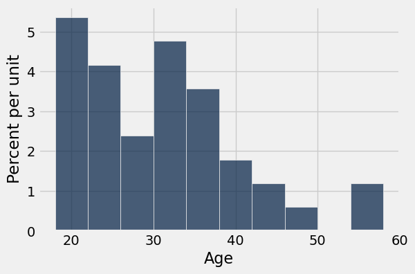

```python
# Distribution of age across Math 108

section_python_age.hist('Age')
```

```python
# section counts

section_python_age.group('Section')
```

| Section | count |
| --- | --- |
| A | 19 |
| B | 17 |
| C | 6 |

```python
# table with average age in each category (instead of counts)

section_python_age.pivot('Section', 'Prior Python Experience', values = 'Age', collect = np.average)
```

| Prior Python Experience | A | B | C |
| --- | --- | --- | --- |
| No | 24.125 | 29.125 | 34.6667 |
| Yes | 31.9091 | 35.3333 | 24.6667 |

### Table Function Visualizer

Check out UC Berkeley's [Table Function Visualizer](https://www.data8.org/interactive_table_functions/) to better understand the `group` and `pivot` table methods.